# The role of statistics in bench biology: Fc-dependent depletion of tumor-infiltrating regulatory T cells co-defines the efficacy of anti–CTLA-4 therapy against melanoma

Jeff Walker

2019-01-08

# Experiment 1

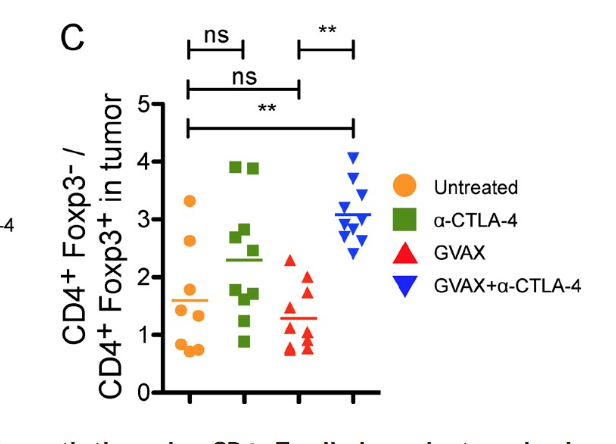

Fig 1C. “GVAX+–CTLA-4 combination therapy protects against tumor outgrowth through a CD4+ T cell–dependent mechanism”

2 x 2 combination of GVAX and alpha-CTLA-4 on tumor growth in C57BL/6 wild-type and I-A-/- (no CD4+ T cell compartment) mouse lines. Combination treatment (but not either in isolation) “protected against” tumor growth in wild but not -/- mice, indicating CD4+ T cell required for protection.

Treatment key: -/- control; +/- alpha-CTLA-4; -/+ GVAX; +/+ both cell key: CD4+Foxp3- Teff; CD4+Foxp3+ Treg

Fig. 1C is the effect of treatment on Neff/Nreg, the ratio of number of effector (Tc) to regulatory (Treg) cells. Thoughts

1. Means but no SE or CI presented.
2. presented as 4 levels instead of 2 x 2 (this seems to be a graphpad prism thing)
3. what is the effect of the distribution of the response (a ratio of counts) on t-tests?
4. F-/- ratio = 1.5, +/+ ratio is 3. Only seem to care about “an effect” with no sense of effect size importance of this effect size or what the minimal effect to care is. For example what if the pattern were maintained with bigger sample and “significant” increase in +/-? How would this effect interpretation of mechanism?

```r
library(ggplot2)
library(data.table)
library(MASS)
niter <- 5000
b1 <- 0
mu_reg.cn <- 10^4
mu_eff.cn <- mu_reg.cn*1.5
mu_reg.trt <- mu_reg.cn*10
mu_eff.trt <- mu_reg.trt*(1.5+b1)
theta <- 5
n <- 10
p_table <- matrix(NA, nrow=niter, ncol=2)
colnames(p_table) <- c("t", "wilcoxon")
ratio_table <- matrix(NA, nrow=niter, ncol=2)
colnames(ratio_table) <- c("cn", "trt")
for(iter in 1:niter){
  # are N_reg and N_eff correlated within individuals?
  N_reg.cn <- rnegbin(n, mu=mu_reg.cn, theta=theta)
  N_eff.cn <- rnegbin(n, mu=mu_eff.cn, theta=theta)
  N_reg.trt <- rnegbin(n, mu=mu_reg.trt, theta=theta)
  N_eff.trt <- rnegbin(n, mu=mu_eff.trt, theta=theta)
  ratio.cn <- N_eff.cn/N_reg.cn
  ratio.trt <- N_eff.trt/N_reg.trt
  ratio_table[iter,] <- c(mean(ratio.cn), mean(ratio.trt))
  p_table[iter, 1] <- t.test(ratio.cn, ratio.trt, var.equal = FALSE)$p.value

  fd <- data.table(N_reg=c(N_reg.cn, N_reg.trt),
                   N_eff=c(N_eff.cn, N_eff.trt),
                   treatment=rep(c("cn", "trt"), each=n))
  p_table[iter, 2] <- wilcox.test(ratio.cn, ratio.trt)$p.value
}
apply(ratio_table, 2, mean)
```

```
##       cn      trt
## 1.874448 1.868908
```

```r
apply(p_table, 2, function(x) length(which(x <= 0.05))/niter)
```

```
##        t wilcoxon
##   0.0376   0.0454
```

# Experiment 2

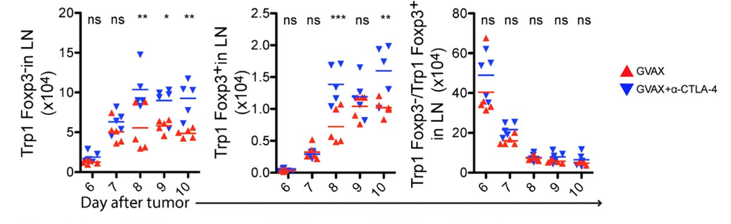

Fig 2B. Cell counts in lymph node. Left panel is Teff. Middle panel is Treg. Right panel is T eff/T reg

“alpha-CTLA-4 increased the absolute numbers of both [Teff and Treg] populations, without changing the Teff/Treg cell ratio”"

1. clear increase variance with mean although the tests are not across days, which contain biggest variation in variance
2. Conclusion of no difference in ratio between -/+ and +/+ based on p > 0.05. Does this matter? What if the ratio were different? Would it effect the interpretation? Or is it just description?

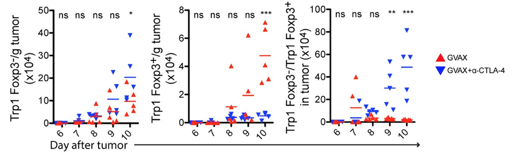

Fig 2C. Cell counts in tumor

1. again, clear increase variance with mean.
2. again, only care about effects With n=5 the p-values are unlikely to be significant without big effect. Example is middle plot at 9 days. Note sampling from Normal is unlikely to give response at 9 days of middle plot (unlikely to sample 2 outliers).

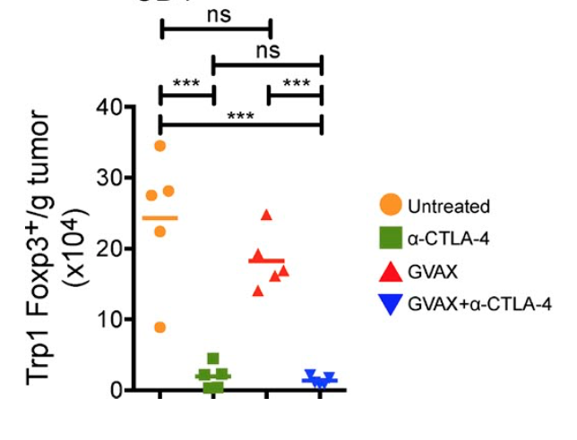

Fig 2D